## Assignment 8

#### Due Friday, November 3, 11:59 PM CT

### Preliminaries

- Directories
  - COURSE/homework/
  - COURSE/homework/hw08/
  - COURSE/data/
  - COURSE/scripts/
- Files
  - COURSE/homework/hw08/hw08.Rmd
  - COURSE/scripts/viridis.R
  - COURSE/scripts/ggprob.R

### Aims

- Practice the binomial distribution

### Problems

1. What is the probability that a sequence of fair, independent coin tosses results in exactly $m$ heads in $n = 2m$ independent coin tosses, when $m$ varies from 1 to 50? Calculate these values using `dbinom()` and plot them versus $n$.

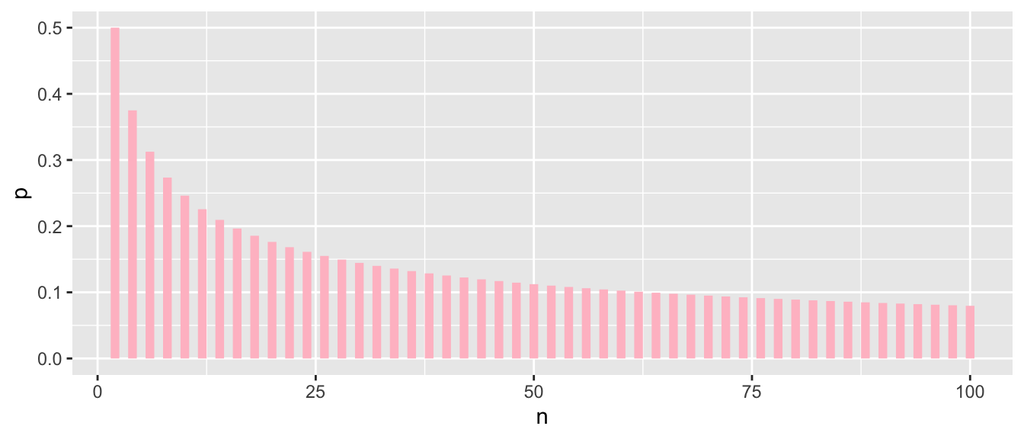

```r
m = 1:50
n = 2*m
p = dbinom(m, n, 0.5)

q1 = data.frame(n, p)

ggplot(q1, aes(x = n, y = p)) +
  geom_segment(aes(xend = n, yend = 0), color = "pink", size = 2)
```

2. Suppose you have a random variable $X \sim \text{Binomial}(120, 0.2)$.
- 2a. Calculate and report the mean and standard deviation of the distribution.

```r
q2a = tibble(x = 0:120, p = dbinom(x, 120, 0.2))

q2a_sum = q2a %>%
  summarize(mu = sum(x * p), sigma2 = sum((x - mu)^2 * p), sigma = sqrt(sigma2))
q2a_sum
```

```
## # A tibble: 1 × 3
##      mu sigma2 sigma
##   <dbl>  <dbl> <dbl>
## 1    24   19.2  4.38
```

- 2b. Calculate and report the probability that the random variable is exactly equal to 20, $\mathsf{P}(X = 20)$. #dbinom()

```r
n = 120
p = 0.2

q2b = dbinom(20, n, p)
q2b
```

```
## [1] 0.06293094
```

- 2c. Calculate and report the probability that $X$ equals 20 or more, $\mathsf{P}(X \ge 20)$.

```r
q2c = 1 - pbinom(19, n, p)
q2c
```

```
## [1] 0.8482865
```

- 2d. Draw a graph of the binomial distribution with vertical lines at the mean (red and dashed), and 1, 2, and 3 standard deviations above and below the mean (red and dotted).

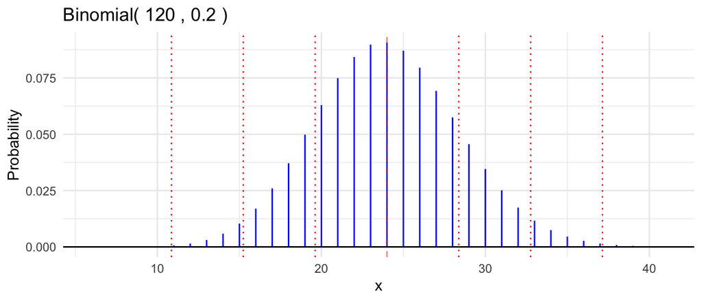

```r
mu = n*p
sigma = sqrt(n*p*(1-p))

gbinom(n, p, scale = TRUE) +
  geom_vline(xintercept = mu, color = "red", linetype = "dashed", alpha = 0.5) +
  geom_vline(xintercept = mu + c(-1,1)*sigma,
             color = "red", linetype = "dotted") +
  geom_vline(xintercept = mu + c(-2,2)*sigma,
             color = "red", linetype = "dotted") +
  geom_vline(xintercept = mu + c(-3,3)*sigma,
             color = "red", linetype = "dotted") +
  theme_minimal()
```

3. What is the probability that $X$ from Problem 2 is within one, two, and three standard deviations of the mean? Round each probability to four decimal places.

```r
val_one_sd = mu + c(-1,1)*sigma
q3_one_sd = pbinom(28.4, n, p) - pbinom(19.6, n, p)
round(q3_one_sd, digits = 4)
```

```
## [1] 0.696
```

```r
val_two_sd = mu + c(-2,2)*sigma
q3_two_sd = pbinom(32.8, n, p) - pbinom(15.2, n, p)
round(q3_two_sd, digits = 4)
```

```
## [1] 0.9486
```

```r
val_three_sd = mu + c(-3,3)*sigma
q3_three_sd = pbinom(37.1, n, p) - pbinom(10.9, n, p)
round(q3_three_sd, digits = 4)
```

```
## [1] 0.9979
```

4. The following code makes a graph of the cumulative distribution function for the $\text{Binomial}(7, 0.3)$ distribution, that is $F(x) = \mathsf{P}(X \le x)$. This is the function which is calculated by the base R function `pbinom()`.
- Modify the code to add a horizontal red dotted line at 0.4.

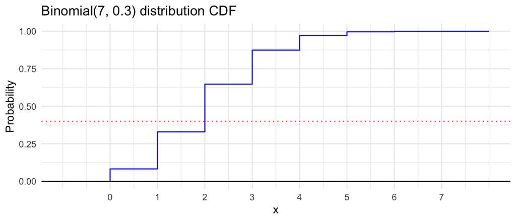

```r
prob4 = tibble(
  x = seq(-1,8,1),
  p = dbinom(x, 7, 0.3),
  cdf = pbinom(x, 7, 0.3))

ggplot(prob4, aes(x = x, y = cdf )) +
  geom_step(color = "blue") +
  geom_hline(yintercept = 0) +
  geom_hline(yintercept = 0.4, color = "red", linetype = "dotted") +
  scale_x_continuous(breaks = 0:7) +
  xlab("x") +
  ylab("Probability") +
  ggtitle("Binomial(7, 0.3) distribution CDF") +
  theme_minimal()
```

- Calculate the 0.4 quantile of the $\text{Binomial}(7, 0.3)$

```r
n = 7
p = 0.3

q4a = qbinom(0.4, n, p)
q4a
```

```
## [1] 2
```

- Explain how the value of the quantile is related to the red dotted line which you added to the plot.

> The red dotted line represents the 0.4 quantile, whose value is 2; we know this because the horizontal line created for this quantile value crosses the vertical line at x = 2, which corresponds to the value of the function.
- Use the graph to determine the 0.75 quantile of this distribution. Then verify your observation with a calculation.

```r
q4b = qbinom(0.75, n, p)
q4b
```

```
## [1] 3
```

5. In a large population of likely voters, the proportion of voters who plan to vote for candidate A is $p = 0.52$. In a random sample of 600 likely voters, what is the probability that the proportion of voters who plan to vote for candidate A is less than 50% (the number of such voters is less than 300)?

```r
n = 600
p = 0.52

q5 = pbinom(300, n, p)
q5
```

```
## [1] 0.1736673
```

6. Basketball player 1 makes 80% of their free throws and basketball player 2 makes 70% of their free throws. Assume all of their free throws attempts are independent. If each player takes ten free throws and $X$ is the total number of free throws they make, does $X$ have a binomial distribution? If yes, specify the parameters $n$ and $p$. If not, explain why not.

> $X$ does not have a binomial distribution. This is because this scenario, which involves combining the total number of free throws made by each player, does not fulfill the “same probability” property of the BINS acronym, as both players do not have the same probability of making a free throw (ex. one could be slightly better at making shots than the other).
7. What is the smallest number of coin tosses $n$ of a fair coin so that the chance of getting 50 or more heads exceeds 90%? (You may need to do some trial and error. Alternatively, think of creating a data frame with a column `n` and a column for the probability and using this to find the answer.)

```r
n = 50:1000
p = 1 - pbinom(49, n, 0.5)

q7 = tibble(n = n, p = p)

q7 %>%
  filter(p > 0.90) %>%
  slice_min(n)
```

```
## # A tibble: 1 × 2
##       n     p
##   <int> <dbl>
## 1   113 0.906
```

8. The random variable $X$ has the $\text{Binomial}(100, 0.2)$ distribution.
- Find an integer $a$ so that $P(X \le a) \ge 0.5$ and $P(X \ge a) \ge 0.5$.
- Show the values of $a$, $P(X \le a)$, and $P(X \ge a)$.

```r
q8a = qbinom(0.5, 100, 0.2) # value of a
q8a
```

```
## [1] 20
```

```r
q8b = pbinom(20, 100, 0.2) # P(X <= 20)
q8b
```

```
## [1] 0.5594616
```

```r
q8c = 1 - pbinom(19, 100, 0.2) # P(X >= 20)
q8c
```

```
## [1] 0.5398386
```